# 대한민국 코로나 바이러스 현황 파악

#### Author: 최의용

#### Github Code: [Unfinishedgod](https://github.com/Unfinishedgod/record_Rcode/blob/master/corona.Rmd)

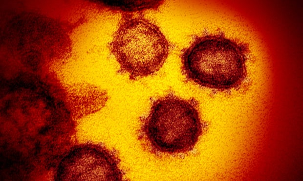

# 코로나바이러스감염증-19 (COVID-19)

**정의**: 2019년 12월 중국 우한에서 처음 발생한 뒤 전 세계로 확산된, 새로운 유형의 코로나바이러스(SARS-CoV-2)에 의한 호흡기 감염질환이다. 코로나바이러스감염증-19는 감염자의 비말(침방울)이 호흡기나 눈·코·입의 점막으로 침투될 때 전염된다. 감염되면 약 2~14일(추정)의 잠복기를 거친 뒤 발열(37.5도) 및 기침이나 호흡곤란 등 호흡기 증상, 폐렴이 주증상으로 나타나지만 무증상 감염 사례도 드물게 나오고 있다.

**[네이버 지식백과] 코로나바이러스감염증-19 - COVID-19 (시사상식사전, pmg 지식엔진연구소)**

# 대한민국 인구/코로나 바이러스 확진자 현황

2020년 3월 5일. 지난 12월 부터 대한민국은 코로나 바이러스로 인해 많은 공포를 느끼고 있다. 처음에는 잠깐의 헤프닝으로 여겼던 현상이, 대구/경북에서 확진자가 폭등 하는 바람에 대한민국을 공포로 물들인게 아닌가 싶다. 나 역시, 한동안 주말에는 계속 집에서 외출은 최소화 하면서 지내고 있는데, 문득 **의문**이 생겨 글을 쓴다. 동시에 이번에 gganimate, ggmap을 배우는 좋은 계기가 되었다.

### 내가 바라본 코로나 바이러스

[figure not shown]

정말, 정말 이정도까지 생각을 하고 있었다. 정말 무서웠으며 집에만 있었었다. 그러다 문득 부산행이며 다른 좀비영화에 나오는 수준의 위험한 정도 일까? 라는 생각이 문득 들었었다. 상당히 위험한 발언일 수 있는데, 결론적으로 내가 스스로 생각 하고 있는것은,

**현 시기에는 많은 경각심을 가져야 한다.**  
**다만, 적어도 심각한 공포가 아니라 심각한 경계라는 생각을 하는게 좋아 보인다.**

어느덧 대한민국 확진자가 3700명을 넘어섰다. 3700명. 많다면 많을 수는 있는 숫자. 그러나 꼬리표처럼 붙어 나오는 키워드가 대구/경북에서 3000명. **나는 여기에 초점을 맞추어 글을 써보려 한다.**

## 시도별 인구/ 확진자 현황

먼저 시도별 인구와 확진자 현황을 보도록 하자. 시도별 인구는 KOSIS[^1]에서 2020년 2월 기준으로 가져왔으며, 코로나 확진자 데이터[^2] 는 박찬엽님의 링크를 사용하였다. 시도별 인구와 확진자 인구를 보면 인구는 서울/경기도에, 확진자는 대구/경북에 몰려 있는것을 확인할 수 있었다. 이를 각각 지도에 시각화 하여 확인해보자.

```r
library(stringi)
library(kormaps2014)
library(tidyverse)
library(googledrive)
library(mapproj)
library(ggiraphExtra)
library(data.table)
library(readxl)
library(patchwork)
library(gridExtra)
library(maps)
library(ggthemes)
library(gganimate)
library(httr)
library(jsonlite)
library(lubridate)
library(scales)
library(DT)

theme_set(theme_bw())

## 대한민국 인구 데이터 추출
population <- read_xls("population_x.xls")

population <- population[,c(1,8)]

colnames(population) <- c("행정구역별_읍면동", "총인구수")

population <- population[-c(1:2),]

korpop2020 <- korpop1 %>%
  left_join(population) %>%
  select(C행정구역별_읍면동, 행정구역별_읍면동, 시점, C행정구역별, code, 총인구수) %>%
  rename(pop2020 = 총인구수, name = 행정구역별_읍면동)

korpop2020$시점 <- 2020
korpop2020$pop2020 <- as.numeric(korpop2020$pop2020)

# 코로나 데이터 추출
corona_0301 <- read_xlsx("corona19_kr_20200301.xlsx")

corona_0301 <- corona_0301 %>%
  select(구분, `확진환자 (명)`) %>%
  filter(!구분 %in% c(NA,"합계", "검역"))


colnames(tbc)[1] <- "구분"

tbc_unique <- tbc %>%
  select(구분, name) %>%
  unique()

corona_0301 <- corona_0301 %>%
  left_join(tbc_unique) %>%
  select(name, `확진환자 (명)`)

kor_pop_corona <- korpop2020 %>%
  left_join(corona_0301) %>%
  rename(pop_corona = `확진환자 (명)`)

kor_pop_corona$pop_corona <- as.numeric(kor_pop_corona$pop_corona)

kor_pop_corona %>%
  rename(총인구수 = pop2020, 확진자 = pop_corona, 행정구역 = name) %>%
  select(시점,총인구수,  확진자, 행정구역) %>%
  datatable(rownames = FALSE)
```

| 시점 | 총인구수 | 확진자 | 행정구역 |
| --- | --- | --- | --- |
| 2020 | 9736962 | 87 | 서울특별시 |
| 2020 | 3410925 | 83 | 부산광역시 |
| 2020 | 2432883 | 2705 | 대구광역시 |
| 2020 | 2954955 | 6 | 인천광역시 |
| 2020 | 1456121 | 9 | 광주광역시 |
| 2020 | 1473125 | 13 | 대전광역시 |
| 2020 | 1145710 | 20 | 울산광역시 |
| 2020 | 343788 | 1 | 세종특별자치시 |
| 2020 | 13265377 | 89 | 경기도 |
| 2020 | 1539521 | 15 | 강원도 |

[output cut: 7 more lines]

## 시도별 인구 현황 지도

먼저, 시도별 인구 현황 지도를 확인해보자. 시각화 참고는 Do it! 쉽게 배우는 R 데이터 분석 Github과, Kormaps 패키지를 이용한 단계구분도 쉽게 그리기[^3]를 참고 했다. 경기도와 서울에 짙은것을 보면 인구가 밀집 되었음을 확인할 수 있엇다.

```r
ggChoropleth(data = korpop2020,      # 지도에 표현할 데이터
             aes(fill = pop2020,      # 색깔로 표현할 변수
                 map_id = code,   # 지역 기준 변수
                 tooltip = name), # 지도 위에 표시할 지역명
             map = kormap1,       # 지도 데이터
             interactive = T)
```

[interactive chart not shown]

## 시도별 코로나 확진자 지도

이번에는 시도별 코로나 확진자 지도를 보자. 대구와 경북에 많이 짙은것을 볼 수 있다.

```r
ggChoropleth(data = kor_pop_corona,      # 지도에 표현할 데이터
             aes(fill = pop_corona,      # 색깔로 표현할 변수
                 map_id = code,   # 지역 기준 변수
                 tooltip = name), # 지도 위에 표시할 지역명
             map = kormap1,       # 지도 데이터
             interactive = T)
```

[interactive chart not shown]

## 코로나 버블 차트

지도를 다른 방법으로 보자. 원래는 이 링크에 나와 있는 것처럼 gganimate를 사용해 움직이는 버블차트를 만들어 보려 했으나[^4], 여러번의 시행착오를 겪어도 할 수가 없었다. 일단 map에 대해 좀 더 공부를 해봐야 겠다. 이 링크대로라면 지역별로 위/경도를 뽑아야 하는데, 이는 xwMOOC의 지리정보 API를 사용한 주소와 위도경도 추출방법을[^5] 참고 하였다.

- [How to plot animated maps with gganimate](https://d4tagirl.com/2017/05/how-to-plot-animated-maps-with-gganimate)

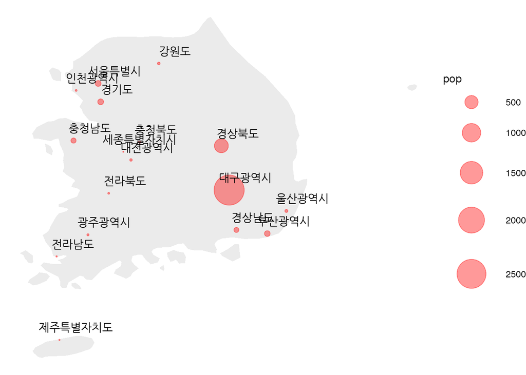

```r
korea <- map_data("world", region = c("South Korea"))

# 지리정보 API를 사용한 위경도 추출
Lat_lon_fun <- function(addr) {
  data_list <-
    GET(url = 'https://dapi.kakao.com/v2/local/search/address.json',
        query = list(query = addr),
        add_headers(Authorization = paste0("KakaoAK ", "2ecacbafd523802f293b245103346b06"))) %>%
    content(as = 'text') %>%
    fromJSON()


  lon_lat_df <- data.frame(location = addr, long = data_list$documents$x, lat = data_list$documents$y)

  return(lon_lat_df)
}


location_list <- corona_0301$name

location_long_lat <- map_dfr(location_list, function(x) {
  Lat_lon_fun(x)
})

corona_0301_bubble <- cbind(corona_0301, location_long_lat[,-1]) %>%
  rename(pop = `확진환자 (명)`)

corona_0301_bubble$pop <- as.numeric(corona_0301_bubble$pop)
corona_0301_bubble$long <- as.numeric(corona_0301_bubble$long)
corona_0301_bubble$lat <- as.numeric(corona_0301_bubble$lat)



ggplot() +
  geom_polygon(data=korea, aes(x=long, y=lat, group=group), fill="grey", alpha= 0.3) +
  geom_point(data=corona_0301_bubble, aes(x=long, y=lat, size = pop), shape = 20, color = "red", alpha = 0.4) +
  scale_size_area(max_size=20) +
  theme_void() +
  geom_text(data=corona_0301_bubble, aes(x=long+0.2, y=lat+0.2, label=name))
```

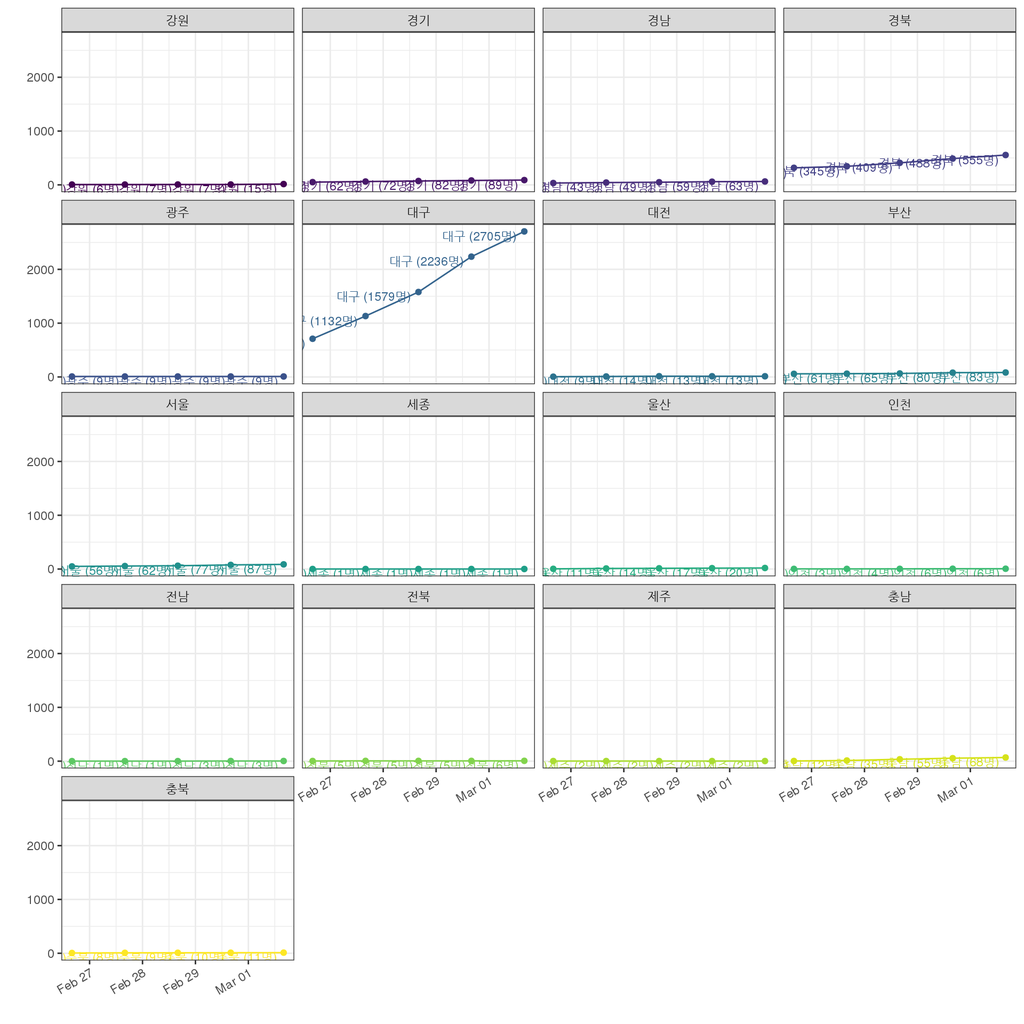

```r
corona_flow <- read_xlsx("corona19-kr.xlsx")

corona_flow_2 <- corona_flow %>%
  filter(location != "검역" & state1 == "확진") %>%
  rename(Day = "datetime(kst)") %>%
  group_by(Day, location, state1) %>%
  summarise(count = sum(count))

datebreaks <- seq(as.Date(head(corona_flow_2$Day,1)), as.Date(tail(corona_flow_2$Day,1)), by="1 day")


p <- corona_flow_2 %>%
  ggplot(aes(Day, count, group = location, color = factor(location))) +
  geom_line() +
  scale_color_viridis_d() +
  labs(x = "", y = "") +
  theme(axis.text.x = element_text(angle=30, hjust=1)) +
  theme(legend.position = "none")

p + facet_wrap(~location, ncol=4)+
  geom_point() +
  geom_text( aes(y = count+1,label=paste0(location, " (",count,"명)")), size=3, vjust=1, hjust=1.1)
```

```r
# +
  # transition_reveal(Day)
```

## 비교 그래프

이번에는 막대그래프로 확인을 해보자. 내가 가장 눈으로 보고 싶었던 그래프다. 이 그래프를 보면 **상대적**의 개념을 한눈에 알아 볼 수 있다. 대한민국에서 3700명과 지역별로 나누었을때의 확진자 수를 볼 수 있다.

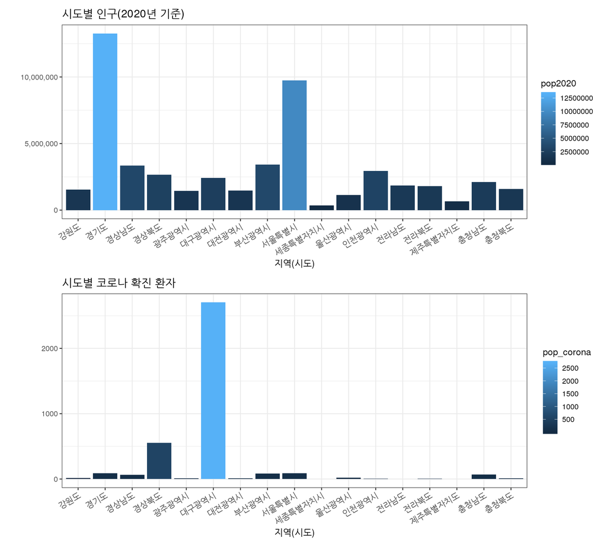

```r
kor_pop_corona_2 <- kor_pop_corona %>%
  gather(key = "case", value = "pops", `pop2020`,`pop_corona`)


p1 <- ggplot(data = kor_pop_corona) +
  geom_col(aes(x = name, y = pop2020, fill = pop2020)) +
  scale_y_continuous(labels = scales::comma) +
  theme(axis.text.x = element_text(size = 10, angle=30, hjust=1)) +
  labs(title = "시도별 인구(2020년 기준)", x = "지역(시도)", y = "", colors = "인구")

p2 <- ggplot(data = kor_pop_corona) +
  geom_col(aes(x = name, y = pop_corona, fill = pop_corona)) +
  theme(axis.text.x = element_text(size = 10, angle=30, hjust=1)) +
  labs(title = "시도별 코로나 확진 환자", x = "지역(시도)", y = "", colors = "인구")

p1 / p2
```

## 지역대비 확진자 파악

점점 결론으로 나아가고 있다. 이번에는 지역대비 확진자의 비율을 파악해보자. 각각 대구와 경북이 0.1112%, 0.0209%이고 그외 지역은 상대적으로 확진자가 낮은것을 볼 수 있다. 다시 말하지만,

**현 시기에는 많은 경각심을 가져야 한다.**  
**다만, 적어도 심각한 공포까진 아니지만 경각심과 공포 그 사이정도**  
**아, 대구/경북 주민은 정말 조심**

```r
kor_pop_corona %>%
  mutate(
    `지역대비 확진자` = paste0(pop_corona , " / ", pop2020),
    `지역대비 확진자 비율` = paste0(format(round(pop_corona / pop2020 * 100, 4), scientific = FALSE),"%")) %>%
  rename(총인구수 = pop2020, 확진자 = pop_corona, 행정구역 = name) %>%
  select(시점,총인구수, 확진자, `지역대비 확진자`, `지역대비 확진자 비율`,행정구역) %>%
  datatable(rownames = FALSE)
```

| 시점 | 총인구수 | 확진자 | 지역대비 확진자 | 지역대비 확진자 비율 | 행정구역 |
| --- | --- | --- | --- | --- | --- |
| 2020 | 9736962 | 87 | 87 / 9736962 | 0.0009% | 서울특별시 |
| 2020 | 3410925 | 83 | 83 / 3410925 | 0.0024% | 부산광역시 |
| 2020 | 2432883 | 2705 | 2705 / 2432883 | 0.1112% | 대구광역시 |
| 2020 | 2954955 | 6 | 6 / 2954955 | 0.0002% | 인천광역시 |
| 2020 | 1456121 | 9 | 9 / 1456121 | 0.0006% | 광주광역시 |
| 2020 | 1473125 | 13 | 13 / 1473125 | 0.0009% | 대전광역시 |
| 2020 | 1145710 | 20 | 20 / 1145710 | 0.0017% | 울산광역시 |
| 2020 | 343788 | 1 | 1 / 343788 | 0.0003% | 세종특별자치시 |
| 2020 | 13265377 | 89 | 89 / 13265377 | 0.0007% | 경기도 |
| 2020 | 1539521 | 15 | 15 / 1539521 | 0.0010% | 강원도 |

[output cut: 7 more lines]

# 총평

사실 코로나의 공포에 휩쌓여, 이미 나는 경각심 보다는 거의 공포에 가까운 수준으로 느끼고 있다. ‘이러면 어쩌나, 저러면 어쩌나, 만약 내가 걸리면 어쩌나.. 등등’ 그러나 애써서 공포를 줄여보고 이성적으로 현 사태를 파악해보고자 이렇게 글을 쓰게되었다. 덕분에 gganimate, ggmap을 공부 하는 좋은 계기가 되었다.

**그래도 다들 조심하시고,**  
**마스크 착용하시고,**  
**손소독 필수,**  
**그리고 사람 많은곳은 피하자구요**

# 참고

[^1]: 행정구역별 인구 데이터  
    - [KOSIS-행정구역(시군구)별, 성별 인구수](http://kosis.kr/statHtml/statHtml.do?orgId=101&tblId=DT_1B040A3&vw_cd=&list_id=&scrId=&seqNo=&lang_mode=ko&obj_var_id=&itm_id=&conn_path=E1)
[^2]: 코로나 데이터 (시도별, 날짜별(2020-02-26~2020-03-01))  
    - [코로나 데이터](https://drive.google.com/drive/folders/1_bjm76OE2H2xluT0D3hScUjvON9DpWXr?fbclid=IwAR2vMDfXFmwqQ8rqZd9MZ2pWJLW02Fczu0o5IZRho66ctypMaT9ppz0YkdY)
[^3]: Kormaps 패키지를 사용한 대한민국 시각화  
    - [Do it! 쉽게 배우는 R 데이터 분석 Github](https://github.com/youngwoos/Doit_R/#91)  
    - [Kormaps 패키지를 이용한 단계구분도 쉽게 그리기(1)](http://web-r.org/webrboard/6477)  
    - [Kormaps 패키지를 이용한 단계구분도 쉽게 그리기(2)](https://rstudio-pubs-static.s3.amazonaws.com/159305_23b365c6973b45d3b14f2a6adc1c71af.html)
[^4]: gganimate & ggmap  
    - [gganimate_map_rpubs](https://d4tagirl.com/2017/05/how-to-plot-animated-maps-with-gganimate)  
    - [Geocomputation with R](https://geocompr.robinlovelace.net/adv-map.html#animated-maps)
[^5]: 지리정보 API를 사용한 주소와 위도경도 추출  
    - [공간통계를 위한 데이터 사이언스](https://statkclee.github.io/spatial/geo-info-lonlat.html)
[^6]: gganimate  
    - [gganimate_exam](https://www.datanovia.com/en/blog/gganimate-how-to-create-plots-with-beautiful-animation-in-r/)  
    - [gganimate_github](https://github.com/thomasp85/gganimate)  
    - [gganimate_tutorial](https://gganimate.com/reference/index.html)